# Strategy, Change, and Analytics: PreModule Assignment 3

Krishna Prasad

14 March, 2020

#### Assignment Instructions:

The attached dataset includes data on each county in the United States, as well as how many Home Depot and Lowe’s locations there are in each county. The assignment (done individually) is to assess how these two chains make decisions on where to locate stores, whether they are different at all, and where they should consider opening new stores in the future.

##### Analysis Questions:

1. How do these two chains make their decisions about where to have store locations? What are the major criteria that drive this decision, and can you provide a very brief rationalization for each? Essentially, this question gets at how the two chains are similar in their decision making.
2. Are there ways in which the two chains are different in the types of locations they target? What are those differences, and why do you think that they may be apparent in the data? Characterize the targeting strategies for each of the two chains.
3. What counties appear underserved in the data, by one or both store chains? Where would you expect Home Depot to open its next 2-3 locations? Lowe’s?

```r
#Load the Data
hl.data <- read_excel("HDL_Data.xls")

hl.data <-
      hl.data %>% rename_all(funs(str_replace(., " ", "_"))) %>% rename_all(tolower)
```

[output not shown]

```r
#convert the factor for regions
hl.data$r1 <- as.factor(hl.data$r1)
hl.data$r2 <- as.factor(hl.data$r2)

#Remove NAs
hl.data <- hl.data %>%
  drop_na()
```

```r
#External Plot for Corr Plot
source("http://www.sthda.com/upload/rquery_cormat.r")

#Consider only numeric columns plots.
corr.plot.fn <- function(corr.data) {
  corr.list <-
    rquery.cormat(corr.data, type = "flatten", graph = FALSE)
  cormat <- rquery.cormat(corr.data, graphType = "heatmap")
  rquery.cormat(corr.data, type = "full")
  corr.list$r
}
```

#### Reviewing correlation accross the data

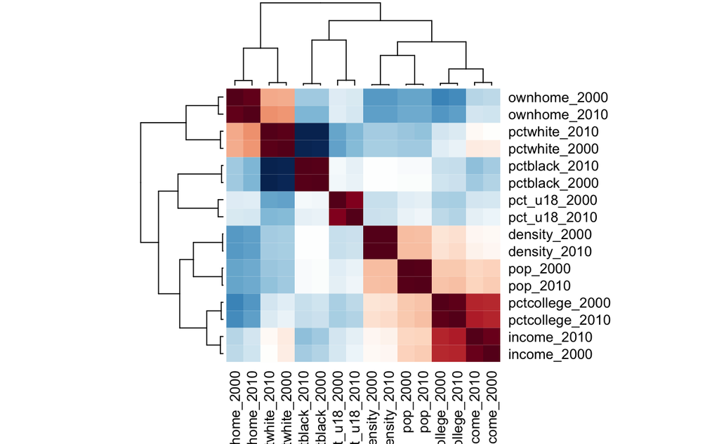

| row | column | cor | p |
| --- | --- | --- | --- |
| pctwhite_2000 | pctwhite_2010 | 0.9800 | 0.0e+00 |
| pctwhite_2000 | ownhome_2000 | 0.3900 | 7.9e-114 |
| pctwhite_2010 | ownhome_2000 | 0.4000 | 9.1e-124 |
| pctwhite_2000 | ownhome_2010 | 0.4500 | 4.4e-157 |
| pctwhite_2010 | ownhome_2010 | 0.4700 | 2.4e-172 |
| ownhome_2000 | ownhome_2010 | 0.9600 | 0.0e+00 |
| pctwhite_2000 | pctcollege_2000 | 0.0150 | 3.9e-01 |
| pctwhite_2010 | pctcollege_2000 | -0.0330 | 6.2e-02 |
| ownhome_2000 | pctcollege_2000 | -0.4200 | 3.4e-134 |
| ownhome_2010 | pctcollege_2000 | -0.3600 | 4.3e-97 |

[output cut: 110 more lines]

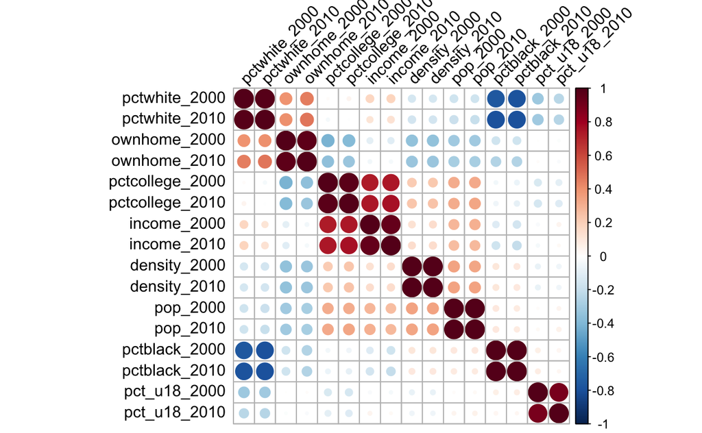

```r
#Create 2000 Data Set
hl.corr.data <- hl.data %>%
  select(-"areaname",-"county",-"state",-"r1", -"r2", -"lcount", -"hdcount")

#Correlation Plot
corr.plot.fn(hl.corr.data)
```

```r
glimpse(hl.data)
```

```
Observations: 3,137
Variables: 23
$ areaname        <chr> "Autauga", "Baldwin", "Barbour", "Bibb", "Blount", "Bullock", "Butler", "C…
$ county          <dbl> 1001, 1003, 1005, 1007, 1009, 1011, 1013, 1015, 1017, 1019, 1021, 1023, 10…
$ state           <chr> "AL", "AL", "AL", "AL", "AL", "AL", "AL", "AL", "AL", "AL", "AL", "AL", "A…
$ r1              <fct> 6, 6, 6, 6, 6, 6, 6, 6, 6, 6, 6, 6, 6, 6, 6, 6, 6, 6, 6, 6, 6, 6, 6, 6, 6,…
$ r2              <fct> 3, 3, 3, 3, 3, 3, 3, 3, 3, 3, 3, 3, 3, 3, 3, 3, 3, 3, 3, 3, 3, 3, 3, 3, 3,…
$ lcount          <dbl> 1, 2, 0, 0, 0, 0, 0, 2, 0, 0, 0, 0, 0, 0, 0, 1, 1, 0, 0, 0, 0, 1, 0, 0, 1,…
$ hdcount         <dbl> 1, 2, 0, 0, 0, 0, 0, 1, 0, 0, 0, 0, 0, 0, 0, 0, 0, 0, 0, 0, 0, 0, 0, 0, 0,…
$ pop_2000        <dbl> 43671, 140415, 29038, 20826, 51024, 11714, 21399, 112249, 36583, 23988, 39…
$ pop_2010        <dbl> 54571, 182265, 27457, 22915, 57322, 10914, 20947, 118572, 34215, 25989, 43…
$ income_2000     <dbl> 48458, 47028, 31877, 37230, 41573, 23990, 30915, 39908, 36598, 36920, 3950…
$ income_2010     <dbl> 63458, 57447, 40109, 51951, 53807, 33763, 39808, 48971, 40753, 47489, 4761…
$ pct_u18_2000    <dbl> 28.6, 24.4, 25.4, 25.4, 25.4, 26.1, 26.9, 23.6, 24.6, 22.2, 25.7, 26.1, 28…
$ pct_u18_2010    <dbl> 26.8, 23.0, 21.9, 22.7, 24.6, 22.3, 24.1, 22.9, 22.5, 21.4, 25.1, 22.7, 24…
$ pctcollege_2000 <dbl> 18.0, 23.1, 10.9, 7.1, 9.6, 7.7, 10.4, 15.2, 9.5, 9.7, 9.9, 9.6, 12.1, 7.8…
$ pctcollege_2010 <dbl> 21.8, 26.6, 12.4, 11.1, 12.3, 9.0, 12.3, 17.5, 10.3, 10.0, 11.3, 10.8, 13.…
$ ownhome_2000    <dbl> 80.8, 79.5, 73.1, 80.2, 83.4, 74.5, 76.2, 72.5, 75.7, 81.7, 82.3, 86.3, 81…
$ ownhome_2010    <dbl> 75.4, 72.5, 66.8, 75.6, 80.6, 68.8, 70.3, 68.8, 70.6, 78.5, 76.6, 83.0, 77…
$ density_2000    <dbl> 73.3, 88.0, 32.8, 33.4, 79.0, 18.7, 27.5, 184.6, 61.3, 43.4, 57.1, 17.4, 2…
$ density_2010    <dbl> 91.8, 114.6, 31.0, 36.8, 88.9, 17.5, 27.0, 195.7, 57.4, 46.9, 63.0, 15.2, …
$ pctwhite_2000   <dbl> 80.7, 87.1, 51.3, 76.7, 95.1, 25.3, 58.4, 78.9, 60.9, 92.8, 86.7, 55.1, 55…
$ pctwhite_2010   <dbl> 78.5, 85.7, 48.0, 75.8, 92.6, 23.0, 54.4, 74.9, 58.8, 92.7, 84.1, 55.8, 54…
$ pctblack_2000   <dbl> 22.1, 12.2, 44.3, 24.2, 1.5, 65.4, 42.5, 21.7, 36.2, 5.0, 10.7, 37.8, 40.7…
$ pctblack_2010   <dbl> 17.7, 9.4, 46.9, 22.0, 1.3, 70.2, 43.4, 20.6, 38.7, 4.6, 9.7, 43.4, 43.9, …
```

```r
hl.hist.data <-
  hl.data %>% dplyr::select(-c("areaname", "county", "state", "r1", "r2"))

str(hl.hist.data)
```

```
Classes ‘tbl_df’, ‘tbl’ and 'data.frame':   3137 obs. of  18 variables:
 $ lcount         : num  1 2 0 0 0 0 0 2 0 0 ...
 $ hdcount        : num  1 2 0 0 0 0 0 1 0 0 ...
 $ pop_2000       : num  43671 140415 29038 20826 51024 ...
 $ pop_2010       : num  54571 182265 27457 22915 57322 ...
 $ income_2000    : num  48458 47028 31877 37230 41573 ...
 $ income_2010    : num  63458 57447 40109 51951 53807 ...
 $ pct_u18_2000   : num  28.6 24.4 25.4 25.4 25.4 26.1 26.9 23.6 24.6 22.2 ...
 $ pct_u18_2010   : num  26.8 23 21.9 22.7 24.6 22.3 24.1 22.9 22.5 21.4 ...
 $ pctcollege_2000: num  18 23.1 10.9 7.1 9.6 7.7 10.4 15.2 9.5 9.7 ...
 $ pctcollege_2010: num  21.8 26.6 12.4 11.1 12.3 9 12.3 17.5 10.3 10 ...
 $ ownhome_2000   : num  80.8 79.5 73.1 80.2 83.4 74.5 76.2 72.5 75.7 81.7 ...
 $ ownhome_2010   : num  75.4 72.5 66.8 75.6 80.6 68.8 70.3 68.8 70.6 78.5 ...
 $ density_2000   : num  73.3 88 32.8 33.4 79 ...
 $ density_2010   : num  91.8 114.6 31 36.8 88.9 ...
 $ pctwhite_2000  : num  80.7 87.1 51.3 76.7 95.1 25.3 58.4 78.9 60.9 92.8 ...
 $ pctwhite_2010  : num  78.5 85.7 48 75.8 92.6 23 54.4 74.9 58.8 92.7 ...
 $ pctblack_2000  : num  22.1 12.2 44.3 24.2 1.5 65.4 42.5 21.7 36.2 5 ...
 $ pctblack_2010  : num  17.7 9.4 46.9 22 1.3 70.2 43.4 20.6 38.7 4.6 ...
```

```r
hl.hist.data <- sapply(hl.hist.data, as.numeric)


ggplot(gather(hl.hist.data), aes(value)) +
  geom_histogram(bins = 10) +
  facet_wrap(~ key, scales = 'free_x')
```

[output not shown]

#### Reviewing the Stores Output by State

```r
hl.data.loc <- hl.data %>%
  select(state, hdcount, lcount) %>%
  gather(key = "location", value = "count", hdcount:lcount) %>%
  group_by(state, location, count, add = TRUE) %>%
  summarise(count1 = sum(count)) %>%
  select(-"count") %>%
  rename(count = count1)

#check the total number of stores by location
hl.data.loc %>%
    group_by(location) %>%
    summarise(count = sum(count))
```

| location | count |
| --- | --- |
| hdcount | 1952 |
| lcount | 1706 |

```r
#check the total number ofs stores by state
hl.data.loc %>%
    group_by(state, location) %>%
    summarise(count = sum(count))
```

| state | location | count |
| --- | --- | --- |
| AK | hdcount | 7 |
| AK | lcount | 5 |
| AL | hdcount | 28 |
| AL | lcount | 39 |
| AR | hdcount | 14 |
| AR | lcount | 20 |
| AZ | hdcount | 55 |
| AZ | lcount | 31 |
| CA | hdcount | 231 |
| CA | lcount | 110 |

[output cut: 92 more lines]

```r
# hl.data %>%
#   select(county, state, HDcount, Lcount) %>%
#   gather(key = "location", value = "count", HDcount:Lcount) %>%
#   group_by(county,location,count, add= TRUE) %>%
#   summarise(count1 = sum(count)) %>%
#   select(-"count") %>%
#   rename(count = count1)
```

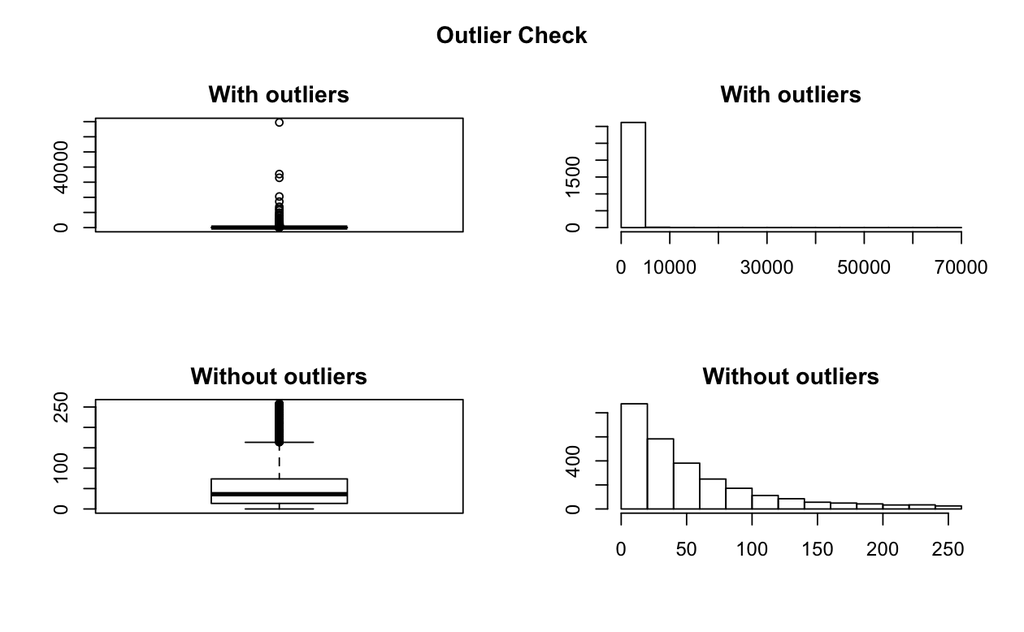

```r
h.data <- hl.data

# h.data <- h.data %>% column_to_rownames(., var = "county")

h.data <- h.data %>%
  mutate(hd_flag = as.factor(if_else(h.data$hdcount == 0, "NO", "YES")))

h.data <- h.data %>% select(-c("r1", "r2")) #"pctcollege_2000", "pctblack_2000", "ownhome_2000", "pct_u18_2010", "pctblack_2010"

h.data <- h.data %>%
  mutate(
    log_density_2000 = log(density_2000),
    log_density_2010 = log(density_2010)
  )

outlierKD(h.data, h.data$density_2010)
yes
```

```r
h.data <- h.data[is.finite(h.data$hd_flag),]
h.data <- h.data[is.finite(h.data$log_density_2000),]
h.data <- h.data[is.finite(h.data$log_density_2010),]


h.data <- h.data[complete.cases(h.data), ]


colSums(is.na(h.data))
```

```
        areaname           county            state           lcount          hdcount         pop_2000         pop_2010      income_2000
               0                0                0                0                0                0                0                0
     income_2010     pct_u18_2000     pct_u18_2010  pctcollege_2000  pctcollege_2010     ownhome_2000     ownhome_2010     density_2000
               0                0                0                0                0                0                0                0
    density_2010    pctwhite_2000    pctwhite_2010    pctblack_2000    pctblack_2010          hd_flag log_density_2000 log_density_2010
               0                0                0                0                0                0                0                0
               $           h.data
               0                0
```

```r
# Execute Boruta
var.boruta <-
  Boruta(
    as.factor(hd_flag) ~ .,
    data = h.data,
    doTrace = 2
  )
```

[output not shown]

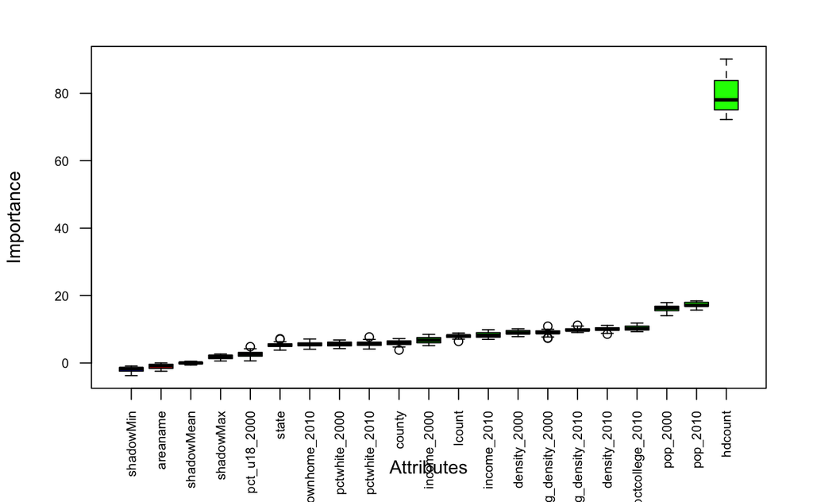

```r
# Plot importance based on the Z Scores
lz <- lapply(1:ncol(var.boruta$ImpHistory), function(i)
  var.boruta$ImpHistory[is.finite(var.boruta$ImpHistory[, i]), i])
names(lz) <- colnames(var.boruta$ImpHistory)
Labels <- sort(sapply(lz, median))
plot(
  var.boruta,
  side = 1,
  las = 2,
  labels = names(Labels),
  at = 1:ncol(var.boruta$ImpHistory),
  cex.axis = 0.7
)
```

```r
final.boruta <- TentativeRoughFix(var.boruta)
```

```
There are no Tentative attributes! Returning original object.
```

```r
getSelectedAttributes(final.boruta, withTentative = F)
```

```
 [1] "county"           "state"            "lcount"           "hdcount"          "pop_2000"         "pop_2010"         "income_2000"
 [8] "income_2010"      "pct_u18_2000"     "pctcollege_2010"  "ownhome_2010"     "density_2000"     "density_2010"     "pctwhite_2000"
[15] "pctwhite_2010"    "log_density_2000" "log_density_2010"
```

```r
boruta.df <- attStats(final.boruta)
print(boruta.df)
```

|  | meanImp | medianImp | minImp | maxImp | normHits | decision |
| --- | --- | --- | --- | --- | --- | --- |
| areaname | -0.9811956 | -0.7977819 | -2.4543602 | 0.02318089 | 0.00 | Rejected |
| county | 5.9993007 | 6.0529354 | 3.8420516 | 7.23911081 | 1.00 | Confirmed |
| state | 5.3325374 | 5.3282923 | 3.8136176 | 7.18275191 | 1.00 | Confirmed |
| lcount | 7.9606692 | 8.0771647 | 6.4012690 | 8.87709302 | 1.00 | Confirmed |
| hdcount | 79.5481585 | 78.0615413 | 72.2041779 | 90.16515906 | 1.00 | Confirmed |
| pop_2000 | 16.1677414 | 16.2633518 | 14.0167355 | 17.90525710 | 1.00 | Confirmed |
| pop_2010 | 17.2025563 | 17.0779961 | 15.6968308 | 18.41160264 | 1.00 | Confirmed |
| income_2000 | 6.7717020 | 6.7761391 | 5.1434849 | 8.49404918 | 1.00 | Confirmed |
| income_2010 | 8.2526309 | 8.2058193 | 7.0035686 | 9.85862128 | 1.00 | Confirmed |
| pct_u18_2000 | 2.6522755 | 2.6611747 | 0.6138958 | 4.83274199 | 0.84 | Confirmed |

[output cut: 8 more lines]

```r
NA
```

```r
glmStepAIC <-
  train(
    as.factor(hd_flag) ~ ., data = h.data,
    method = "glmStepAIC",
    allowParallel = TRUE
  )
```

```r
model.glm <-
  glm(
    as.factor(hd_flag) ~ pop_2010 + income_2010 + ownhome_2010 + pctblack_2010,
    data = h.data,
    family = binomial
  )
```

```
glm.fit: fitted probabilities numerically 0 or 1 occurred
```

```r
summary(model.glm)
```

```
Call:
glm(formula = as.factor(hd_flag) ~ pop_2010 + income_2010 + ownhome_2010 +
    pctblack_2010, family = binomial, data = h.data)

Deviance Residuals:
    Min       1Q   Median       3Q      Max
-3.2542  -0.3578  -0.2403  -0.1830   2.8980

Coefficients:
                Estimate Std. Error z value Pr(>|z|)
(Intercept)   -2.499e+00  8.661e-01  -2.886 0.003907 **
pop_2010       4.545e-05  2.350e-06  19.336  < 2e-16 ***
income_2010    2.546e-05  7.611e-06   3.346 0.000820 ***
ownhome_2010  -3.701e-02  1.045e-02  -3.541 0.000399 ***
pctblack_2010 -2.150e-02  7.573e-03  -2.839 0.004518 **
---
Signif. codes:  0 ‘***’ 0.001 ‘**’ 0.01 ‘*’ 0.05 ‘.’ 0.1 ‘ ’ 1

(Dispersion parameter for binomial family taken to be 1)

    Null deviance: 2277.2  on 2693  degrees of freedom
Residual deviance: 1265.5  on 2689  degrees of freedom
AIC: 1275.5

Number of Fisher Scoring iterations: 7
```

```r
glm.probs <- predict(model.glm,type = "response")
results <- cbind(h.data, glm.probs)

no.hd <-
  results %>% select(
    areaname,
    county,
    hdcount,
    pop_2010,
    income_2010,
    ownhome_2010,
    density_2010,
    log_density_2010,
    pctblack_2010,
    pctwhite_2010,
    state,
    hd_flag,
    glm.probs
  ) %>%
  filter(as.character(hd_flag) == "NO" &
           results$glm.probs >= 0.95) %>%
  arrange(desc(glm.probs))

no.1.hd <-
  results %>% select(
    areaname,
    county,
    hdcount,
    pop_2010,
    income_2010,
    ownhome_2010,
    density_2010,
    log_density_2010,
    pctblack_2010,
    pctwhite_2010,
    state,
    hd_flag,
    glm.probs
  ) %>%
  filter(as.character(hd_flag) == "YES" &
           results$hdcount == 1 &
           results$glm.probs >= 0.95) %>%
  arrange(desc(glm.probs))
```

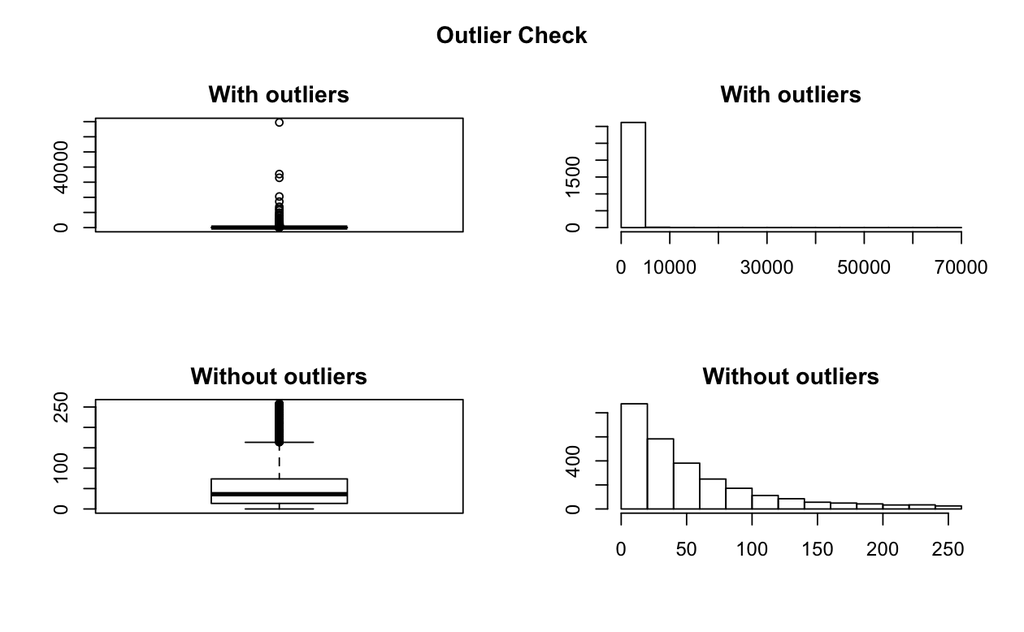

```r
l.data <- hl.data

# h.data <- h.data %>% column_to_rownames(., var = "county")

l.data <- l.data %>%
  mutate(l_flag = as.factor(if_else(l.data$lcount == 0, "NO", "YES")))

l.data <- l.data %>% select(-c("lcount", "hdcount", "r1", "r2"))

l.data <- l.data %>%
  mutate(
    log_density_2000 = log(density_2000),
    log_density_2010 = log(density_2010)
  )
outlierKD(l.data, l.data$density_2010)
yes
```

```r
l.data <- l.data[is.finite(l.data$l_flag),]
l.data <- l.data[is.finite(l.data$log_density_2000),]
l.data <- l.data[is.finite(l.data$log_density_2010),]

l.data <- l.data[complete.cases(l.data), ]

colSums(is.na(l.data))
```

```
        areaname           county            state         pop_2000         pop_2010      income_2000      income_2010     pct_u18_2000     pct_u18_2010
               0                0                0                0                0                0                0                0                0
 pctcollege_2000  pctcollege_2010     ownhome_2000     ownhome_2010     density_2000     density_2010    pctwhite_2000    pctwhite_2010    pctblack_2000
               0                0                0                0                0                0                0                0                0
   pctblack_2010           l_flag log_density_2000 log_density_2010                $           l.data
               0                0                0                0                0                0
```

```r
# Execute Boruta
var.boruta <-
  Boruta(
    as.factor(l_flag) ~ pop_2010 + ownhome_2010 + density_2010 + pctwhite_2010 + pctblack_2010,
    data = l.data,
    doTrace = 2
  )
```

```
 1. run of importance source...
 2. run of importance source...
 3. run of importance source...
 4. run of importance source...
 5. run of importance source...
 6. run of importance source...
 7. run of importance source...
 8. run of importance source...
 9. run of importance source...
After 9 iterations, +3 secs:
 confirmed 5 attributes: density_2010, ownhome_2010, pctblack_2010, pctwhite_2010, pop_2010;
 no more attributes left.
```

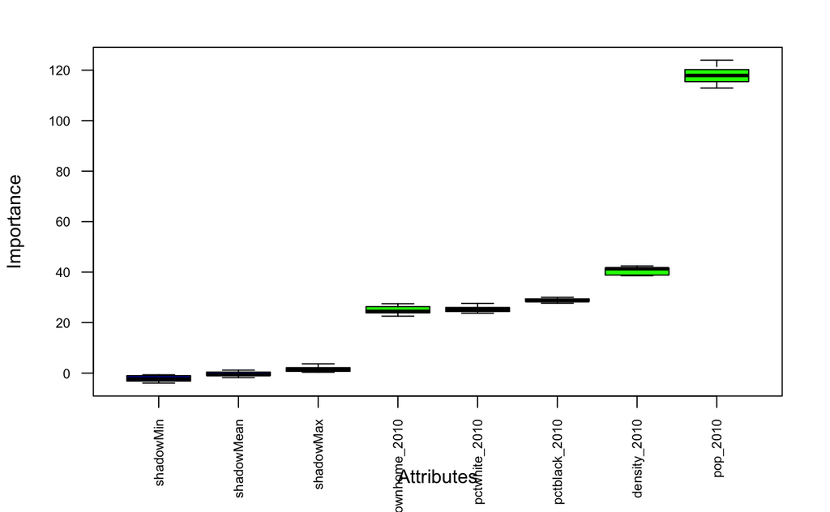

```r
# Plot importance based on the Z Scores
lz <- lapply(1:ncol(var.boruta$ImpHistory), function(i)
  var.boruta$ImpHistory[is.finite(var.boruta$ImpHistory[, i]), i])
names(lz) <- colnames(var.boruta$ImpHistory)
Labels <- sort(sapply(lz, median))
plot(
  var.boruta,
  side = 1,
  las = 2,
  labels = names(Labels),
  at = 1:ncol(var.boruta$ImpHistory),
  cex.axis = 0.7
)
```

```r
final.boruta <- TentativeRoughFix(var.boruta)
```

```
There are no Tentative attributes! Returning original object.
```

```r
getSelectedAttributes(final.boruta, withTentative = F)
```

```
[1] "pop_2010"      "ownhome_2010"  "density_2010"  "pctwhite_2010" "pctblack_2010"
```

```r
boruta.df <- attStats(final.boruta)
print(boruta.df)
```

|  | meanImp | medianImp | minImp | maxImp | normHits | decision |
| --- | --- | --- | --- | --- | --- | --- |
| pop_2010 | 117.99248 | 117.89545 | 112.90996 | 123.94514 | 1 | Confirmed |
| ownhome_2010 | 24.83286 | 24.43976 | 22.54139 | 27.48308 | 1 | Confirmed |
| density_2010 | 40.56308 | 41.35254 | 38.58002 | 42.43057 | 1 | Confirmed |
| pctwhite_2010 | 25.34490 | 25.14016 | 23.73196 | 27.60575 | 1 | Confirmed |
| pctblack_2010 | 28.82003 | 28.66751 | 27.67844 | 30.02336 | 1 | Confirmed |

```r
NA
```

```r
l.aic.data <- l.data %>% select(-c("county"))
glmStepAIC <-
  train(
    l_flag ~ ., data = l.aic.data,
    method = "glmStepAIC",
    allowParallel = TRUE
  )
summary(glmStepAIC)
# varImp(glmStepAIC)
# plot(varImp(glmStepAIC))
```

[output not shown]

```r
model.ldata.glm <-
  glm(
    l_flag ~  pop_2010 + ownhome_2010 + pctwhite_2010 + pctblack_2010 + income_2010,
    data = l.data,
    family = binomial
  )
```

```
glm.fit: fitted probabilities numerically 0 or 1 occurred
```

```r
summary(model.ldata.glm)
```

```
Call:
glm(formula = l_flag ~ pop_2010 + ownhome_2010 + pctwhite_2010 +
    pctblack_2010 + income_2010, family = binomial, data = l.data)

Deviance Residuals:
    Min       1Q   Median       3Q      Max
-6.3591  -0.4206  -0.2773  -0.1891   2.6251

Coefficients:
                Estimate Std. Error z value Pr(>|z|)
(Intercept)   -2.173e+00  1.102e+00  -1.972 0.048597 *
pop_2010       5.721e-05  2.777e-06  20.603  < 2e-16 ***
ownhome_2010  -5.260e-02  1.110e-02  -4.737 2.17e-06 ***
pctwhite_2010  3.634e-02  1.027e-02   3.537 0.000404 ***
pctblack_2010  3.631e-02  1.039e-02   3.495 0.000474 ***
income_2010   -2.450e-05  7.919e-06  -3.094 0.001974 **
---
Signif. codes:  0 ‘***’ 0.001 ‘**’ 0.01 ‘*’ 0.05 ‘.’ 0.1 ‘ ’ 1

(Dispersion parameter for binomial family taken to be 1)

    Null deviance: 2710.5  on 2693  degrees of freedom
Residual deviance: 1515.6  on 2688  degrees of freedom
AIC: 1527.6

Number of Fisher Scoring iterations: 7
```

```r
ldata.glm.probs <- predict(model.ldata.glm, type = "response")
results.ldata <- cbind(l.data, ldata.glm.probs)

no.l <-
  results.ldata %>% select(areaname, county, state, pop_2010, ownhome_2010, density_2010, log_density_2010, pctwhite_2010, pctblack_2010, l_flag, ldata.glm.probs) %>%
  filter(as.character(l_flag) == "NO" &
           results.ldata$ldata.glm.probs >= 0.95) %>%
  arrange(desc(ldata.glm.probs))

no.l.1 <-
  results.ldata %>% select(areaname, county, state, pop_2010, ownhome_2010, density_2010, log_density_2010, pctwhite_2010, pctblack_2010, l_flag, ldata.glm.probs) %>%
  filter(as.character(l_flag) == "YES" &
           results$lcount == 1 &
           results.ldata$ldata.glm.probs >= 0.95) %>%
  arrange(desc(ldata.glm.probs))
```

```r
hl.data <- hl.data %>%
  mutate(hd.pop2010.ratio = hdcount / pop_2010 * 10000)
```